# FigureYa53 PPImodule

小丫画图出品

2018-11-11

小丫微信: epigenomics E-mail: figureya@126.com

作者：加大发

小丫编辑校验

## 需求描述

通过已知PPI数据库找到共表达蛋白中的module，输出到文件，用于下一步cytoscape展示。

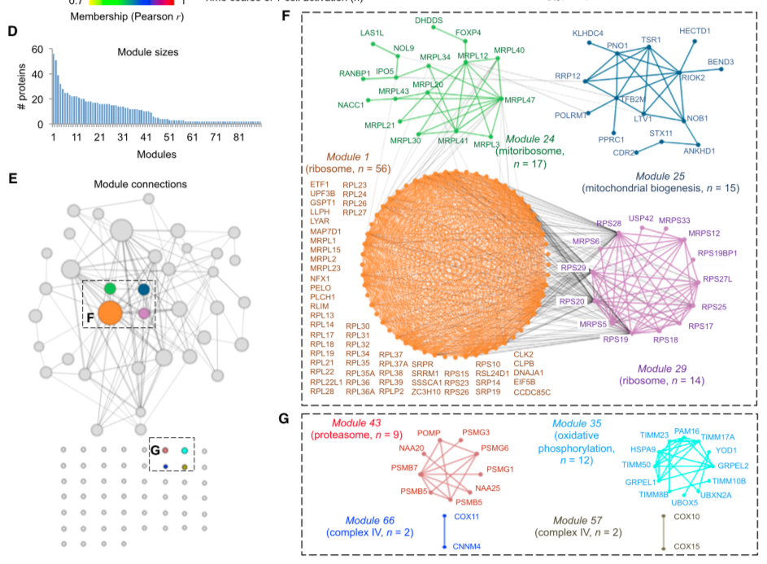

出自https://www.sciencedirect.com/science/article/pii/S1074761317300729?via%3Dihub

## 应用场景

把自己的基因列表跟蛋白相互作用网络联系起来。

例如RNA-seq获得的差异表达基因，看他们在蛋白相互作用网络中，哪些基因处于同一module。

## 环境设置

安装需要的包

```r
#使用国内镜像安装包
options("repos"= c(CRAN="https://mirrors.tuna.tsinghua.edu.cn/CRAN/"))
install.packages("dynamicTreeCut")
install.packages("openxlsx")
install.packages("stringr")
install.packages("Matrix")
install.packages("WGCNA")
```

加载需要用到的包

```r
library(dynamicTreeCut)
library(openxlsx)
library(stringr)
library(Matrix)
library(WGCNA)
Sys.setenv(LANGUAGE = "en") #显示英文报错信息
options(stringsAsFactors = FALSE) #禁止chr转成factor
```

## 输入文件

需要3个文件：

- 共表达基因列表，此处用paper附件里的mm2.xlsx
- Uniprot ID转换文件：ftp://ftp.uniprot.org/pub/databases/uniprot/current_release/knowledgebase/idmapping/by_organism/MOUSE_10090_idmapping_selected.tab.gz
- 从STRING数据库下载PPI数据https://stringdb-static.org/download/protein.actions.v10.5/10090.protein.actions.v10.5.txt.gz。三个红框表示：数据库版本号，物种搜索框，相互作用数据（包含相互作用类型，如物理相互作用)。注意版本号，以及物种搜索框内为‘Mus musculus’，下载第三个框内文件。

[figure not shown]

### 从paper附件获得WPC3基因及蛋白ID

```r
wpc <- read.xlsx("mmc2.xlsx",cols=2:4,startRow = 3) #读入文件第一个sheet中的第2:4列，从第3行开始
wpc3 <- wpc[wpc$WPC==3&!is.na(wpc$WPC),]

uniprot_wpc3 <- str_split(wpc3$Protein.Accession,"[|]",3,simplify = T)[,2]
uniprot_wpc3 <- str_split(uniprot_wpc3,"[-]",2,simplify = T)[,1]
wpc3$uniprot <- uniprot_wpc3
```

### 根据Uniprot ID提取ENSEMBLPROT ID

```r
idmapping<-read.table("MOUSE_10090_idmapping_selected.tab",header = F,as.is=T,sep="\t")
rownames(idmapping)<-idmapping$V1
ids_wpc3 <- idmapping[intersect(uniprot_wpc3,rownames(idmapping)),][,c(1,21)]
dim(ids_wpc3)#由于uniprot版本问题会丢失10个蛋白
```

```
## [1] 1421    2
```

```r
prots <- str_split(ids_wpc3$V21,"; ")
names(prots)<- rownames(ids_wpc3)
prots <- prots[prots!=""]
prots_tmp <- unlist(lapply(seq_along(prots), function(x) paste(names(prots)[x], prots[[x]],sep=";")))
prots_mat <- data.frame(str_split(prots_tmp,"[;]",2,simplify = T),stringsAsFactors = F)
colnames(prots_mat) <- c("uniprot","ensemblprot")
head(prots_mat)
```

```
##   uniprot        ensemblprot
## 1  G3UW58 ENSMUSP00000139512
## 2  Q6PGK3 ENSMUSP00000021406
## 3  D3YZ60 ENSMUSP00000120446
## 4  E9QJR0 ENSMUSP00000025358
## 5  Q8C5X1 ENSMUSP00000082730
## 6  Q8C5X1 ENSMUSP00000103709
```

```r
gene_ensemblprot <- merge(wpc3,prots_mat,by="uniprot")
gene2ensemblprot <- gene_ensemblprot[,c(1,3,ncol(gene_ensemblprot))]
head(gene2ensemblprot)#后面会用到gene和ensemblprot id的对应关系
```

```
##      uniprot Gene.Names        ensemblprot
## 1 A0A087WQH8    Slc35a4 ENSMUSP00000140201
## 2 A0A087WRM0       Cdv3 ENSMUSP00000140690
## 3     A0JNY3       Gphn ENSMUSP00000106018
## 4     A2A5S3      Stau1 ENSMUSP00000104861
## 5     A2A6Q5      Cdc27 ENSMUSP00000091452
## 6     A2A6Q5      Cdc27 ENSMUSP00000102575
```

```r
ensemblprot_wpc3 <- unique(prots_mat$ensemblprot)
```

### 从STRING数据库提取WPC3蛋白的PPI

从STRING数据库提取WPC3蛋白的PPI，把蛋白名转成基因名

STRING数据文件10090.protein.actions.v10.5.txt有580M，我这里8G内存，读取它需要大概30s

```r
ppi <- read.table("10090.protein.actions.v10.5.txt",header=T,sep = "\t")
head(ppi)
```

```
##                  item_id_a                item_id_b       mode     action
## 1 10090.ENSMUSP00000000001 10090.ENSMUSP00000033626    binding
## 2 10090.ENSMUSP00000000001 10090.ENSMUSP00000033617 activation activation
## 3 10090.ENSMUSP00000000001 10090.ENSMUSP00000033626   reaction
## 4 10090.ENSMUSP00000000001 10090.ENSMUSP00000033626    binding
## 5 10090.ENSMUSP00000000001 10090.ENSMUSP00000033626  catalysis
## 6 10090.ENSMUSP00000000001 10090.ENSMUSP00000033626  catalysis
##   is_directional a_is_acting score
## 1              f           f   153
## 2              f           f   155
## 3              f           f   153
## 4              f           t   153
## 5              t           t   153
## 6              t           f   153
```

```r
ppi$item_id_a <- str_replace(ppi$item_id_a,"10090.","")
ppi$item_id_b <- str_replace(ppi$item_id_b,"10090.","")
ppi_wpc3 <- ppi[(ppi$item_id_a %in% ensemblprot_wpc3)&(ppi$item_id_b %in% ensemblprot_wpc3),]
ppi_wpc3 <- ppi_wpc3[!duplicated(paste0(ppi_wpc3$item_id_a,ppi_wpc3$item_id_b)),]#去掉重复行

colnames(ppi_wpc3)[1]<-"ensemblprot"
ppi_gene1st <- merge(ppi_wpc3,gene2ensemblprot,by="ensemblprot")
colnames(gene2ensemblprot)[3] <- "item_id_b"
ppi_gene2nd <- merge(ppi_gene1st,gene2ensemblprot,by="item_id_b")
ppi_gene2nd <- ppi_gene2nd[!duplicated(paste0(ppi_gene2nd$Gene.Names.x,ppi_gene2nd$Gene.Names.y)),]
head(ppi_gene2nd)
```

```
##            item_id_b        ensemblprot      mode action is_directional
## 1 ENSMUSP00000000199 ENSMUSP00000041702   binding                     f
## 2 ENSMUSP00000000199 ENSMUSP00000038772 catalysis                     t
## 3 ENSMUSP00000000199 ENSMUSP00000104069  reaction                     t
## 6 ENSMUSP00000000199 ENSMUSP00000111535   binding                     f
## 7 ENSMUSP00000000199 ENSMUSP00000050680   binding                     f
## 8 ENSMUSP00000000199 ENSMUSP00000003850   binding                     f
##   a_is_acting score uniprot.x Gene.Names.x uniprot.y Gene.Names.y
## 1           t   154    P63141        Kcna2    Q8BNY6         Ncs1
## 2           f   154    Q9JLB0         Mpp6    Q8BNY6         Ncs1
## 3           t   157    Q9WTI7        Myo1c    Q8BNY6         Ncs1
## 6           f   154    G5E8S8         Mpp7    Q8BNY6         Ncs1
## 7           t   154    P16390        Kcna3    Q8BNY6         Ncs1
## 8           f   185    Q7TS72        Itpkc    Q8BNY6         Ncs1
```

```r
genes <- sort(unique(union(ppi_gene2nd$Gene.Names.x,ppi_gene2nd$Gene.Names.y)))
#保存到文件
write.csv(data.frame(genes),file="ppi_gene.csv",row.names = F,quote = F)
```

以对称矩阵的形式表示网络的边，0表示两点之间无连边，1表示有边

```r
pos <- seq_along(genes)
names(pos) <- genes
ppi_gene2nd$posx <- pos[ppi_gene2nd$Gene.Names.x]
ppi_gene2nd$posy <- pos[ppi_gene2nd$Gene.Names.y]

#构建稀疏矩阵
ppi_mat <- sparseMatrix(ppi_gene2nd$posx, ppi_gene2nd$posy, x = 1, dims = c(length(genes), length(genes)))
#保存到文件
write.csv(as.matrix(ppi_mat),file="ppi_mat.csv",row.names = F,quote = F)
```

这时可以中场休息一下，下面继续

```r
NodeNames <- read.csv("ppi_gene.csv", header=T)
NodeNames <- as.vector(NodeNames[,1])
head(NodeNames)
```

```
## [1] "4833403I15Rik" "A630001G21Rik" "Aamp"          "Aars"
## [5] "Aasdhppt"      "Abcb1b"
```

```r
ADJ <- read.csv("ppi_mat.csv", header=T)
ADJ <- as.matrix(ADJ)
rownames(ADJ) <- NodeNames
colnames(ADJ) <- NodeNames
ADJ[1:3,1:3]
```

```
##               4833403I15Rik A630001G21Rik Aamp
## 4833403I15Rik             0             0    0
## A630001G21Rik             0             0    0
## Aamp                      0             0    0
```

## 计算TOM

用到函数TOMdist1，保存在TOMdist1.R文件中，位于当前文件夹。

来自：https://horvath.genetics.ucla.edu/html/GeneralFramework/NetworkFunctions.txt

```r
source("TOMdist1.R") #保存在当前文件夹

# We used the TOM matrix as a smoothed-out version of the adjacency matrix.
dissTOM <- TOMdist1(as.matrix(ADJ))
dissTOM[1:3, 1:3]
```

```
##               4833403I15Rik A630001G21Rik Aamp
## 4833403I15Rik             1             1    1
## A630001G21Rik             1             1    1
## Aamp                      1             1    1
```

## 通过cut tree找module

用R包dynamicTreeCut实现。根据文章Supplemental Information描述：

Now we carry out hierarchical clustering with the TOM matrix. Branches of the resulting clustering tree will be used to define gene modules.

```r
library(dynamicTreeCut)

#基于TOM(topological overlap matrix)对基因进行层次聚类
#可以通过设置method参数，使用不同方法进行层次聚类，如median,complete, centroid等
hierTOM <- hclust(as.dist(dissTOM), method="average")
str(hierTOM)
```

```
## List of 7
##  $ merge      : int [1:888, 1:2] -3 -188 -147 -78 -97 -185 -201 -512 -646 -644 ...
##  $ height     : num [1:888] 0 0 0 0 0 0 0 0 0 0 ...
##  $ order      : int [1:889] 622 149 551 285 561 414 415 54 600 55 ...
##  $ labels     : chr [1:889] "4833403I15Rik" "A630001G21Rik" "Aamp" "Aars" ...
##  $ method     : chr "average"
##  $ call       : language hclust(d = as.dist(dissTOM), method = "average")
##  $ dist.method: NULL
##  - attr(*, "class")= chr "hclust"
```

```r
#使用hybrid dynamic tree-cutting方法，将网络划分成模块
#可以通过设置minClusterSize来调整模块的最小大小
#minClusterSize的默认设置是20，因为通常太小的模块没有意义
#由于文章中的最小模块是2，所以在此我们设置为2
mods <- cutreeDynamic(hierTOM, cutHeight = NULL, minClusterSize = 2,method = "hybrid", distM = dissTOM)
```

```
##  ..cutHeight not given, setting it to 0.99  ===>  99% of the (truncated) height range in dendro.
##  ..done.
```

```r
table(mods)
```

```
## mods
##   1   2   3   4   5   6   7   8   9  10  11  12  13  14  15  16  17  18
##  72  35  32  29  18  16  16  14  13  12  11  11  10  10   9   9   8   8
##  19  20  21  22  23  24  25  26  27  28  29  30  31  32  33  34  35  36
##   8   7   7   7   7   6   6   6   6   6   6   6   6   6   5   5   5   5
##  37  38  39  40  41  42  43  44  45  46  47  48  49  50  51  52  53  54
##   5   5   5   5   5   5   5   5   5   4   4   4   4   4   4   4   4   4
##  55  56  57  58  59  60  61  62  63  64  65  66  67  68  69  70  71  72
##   4   4   4   4   4   4   4   4   4   4   4   4   4   4   3   3   3   3
##  73  74  75  76  77  78  79  80  81  82  83  84  85  86  87  88  89  90
##   3   3   3   3   3   3   3   3   3   3   3   3   3   3   3   3   3   3
##  91  92  93  94  95  96  97  98  99 100 101 102 103 104 105 106 107 108
##   3   3   3   3   3   3   3   3   3   3   3   3   3   2   2   2   2   2
## 109 110 111 112 113 114 115 116 117 118 119 120 121 122 123 124 125 126
##   2   2   2   2   2   2   2   2   2   2   2   2   2   2   2   2   2   2
## 127 128 129 130 131 132 133 134 135 136 137 138 139 140 141 142 143 144
##   2   2   2   2   2   2   2   2   2   2   2   2   2   2   2   2   2   2
## 145 146 147 148 149 150 151 152 153 154 155 156 157 158 159 160 161 162
##   2   2   2   2   2   2   2   2   2   2   2   2   2   2   2   2   2   2
## 163 164 165 166 167 168 169 170 171 172 173 174 175 176 177 178 179 180
##   2   2   2   2   2   2   2   2   2   2   2   2   2   2   2   2   2   2
## 181 182 183 184 185 186 187 188 189 190 191 192 193 194 195 196 197 198
##   2   2   2   2   2   2   2   2   2   2   2   2   2   2   2   2   2   2
## 199 200 201 202 203 204 205
##   2   2   2   2   2   2   2
```

```r
# 将每个模块包含什么基因输出来，result_module.csv
list2<-c()
for (i in names(table(mods))){
    a <- paste(NodeNames[which(mods==i)], sep="", collapse=',')
    list2 <- c(list2,a)
}
list1 <- paste("Module_",names(table(mods)), sep="")
out_df <- data.frame(list1,list2)
write.csv(out_df,'result_module.csv',row.names=FALSE)

# 转成cytoscape，为fig2.F和fig2.G做准备
library(WGCNA)
#输出整个子网络的边和节点情况
exportNetworkToCytoscape(ADJ,
edgeFile = paste('./result_filtered_PPI_network_edge.txt'),
nodeFile = paste('./result_filtered_PPI_network_node.txt'),
weighted = TRUE,
threshold = 0.5,
nodeNames = NodeNames,
altNodeNames = NULL,
nodeAttr = mods,
includeColNames = TRUE)
```

```
## $edgeData
##            fromNode    toNode weight  direction fromAltName toAltName
## 1     4833403I15Rik      Orc3      1 undirected          NA        NA
## 2     4833403I15Rik      Orc4      1 undirected          NA        NA
## 3     4833403I15Rik     Prkci      1 undirected          NA        NA
## 4     4833403I15Rik    Slc2a1      1 undirected          NA        NA
## 5     4833403I15Rik    Trip10      1 undirected          NA        NA
## 6     A630001G21Rik      Hat1      1 undirected          NA        NA
## 7     A630001G21Rik     Hdac7      1 undirected          NA        NA
## 8     A630001G21Rik     Strap      1 undirected          NA        NA
## 9     A630001G21Rik      Wwp2      1 undirected          NA        NA
## 10             Aamp     Eif3f      1 undirected          NA        NA
## 11             Aars    Eif2b1      1 undirected          NA        NA
## 12             Aars    Eif2b4      1 undirected          NA        NA
## 13             Aars      Mars      1 undirected          NA        NA
```

[output cut: 12001 more lines]

这一步生成的两个文件，可以作为cytoscape的输入：

- result_filtered_PPI_network_edge.txt
- result_filtered_PPI_network_node.txt

## 参考文献

Dong J, Horvath S (2007) Understanding Network Concepts in Modules, BMC Systems Biology 2007, 1:24 PMID: 17547772 PMCID: PMC3238286